# Assignment 3 - 42028- group 25

## Initialization

Install and import the required libraries.

```python
pip install torch torchvision
```

```
WARNING: Running pip as the 'root' user can result in broken permissions and conflicting behaviour with the system package manager. It is recommended to use a virtual environment instead: https://pip.pypa.io/warnings/venv
```

```python
import os
import cv2
import numpy as np
import pandas as pd
from sklearn.preprocessing import StandardScaler
from sklearn.decomposition import PCA, IncrementalPCA
from sklearn.cluster import KMeans
import matplotlib.pyplot as plt
from scipy.ndimage.morphology import binary_dilation as dilate
from scipy.ndimage.morphology import binary_erosion as erode
from sklearn.metrics import accuracy_score, balanced_accuracy_score
import torch
import torch.nn as nn
import torchvision.models as models
import tensorflow as tf
import pickle
```

Define the parameters used in the CNN feature dictionary.

```python
#type of object in the pictures
OBJECT_TYPE = "screw"
#type of defect in the objects
DEFECT_TYPE = "scratch_neck"
#size of the image (in pixels) after the rescaling
IMG_SIZE = 128
#size of the patches (in pixels), that are later used in the feature extraction
PATCH_SIZE = 6
#stride (in pixels) between the patches
STRIDE = 4
#batches to extract the features with the CNN without crashing the kernel
FEATURE_EXTRACTION_BATCH_SIZE = 50
#% of variance explained by the PCA
EXPLAINED_VARIANCE = 0.95
#number of clusters of the k-means
N_CLUSTERS = 10
#number of lowest distances to average when creating the mask of anomalies
N_LOWEST_DISTANCES = 3
#threshold of the heavyside distance (in units of std)
ALPHA = 6.75
#parameter used in the discretization of the anomalies mask
ITERATE = 5
```

Function to retrieve the defect-free images used for train, together with the defective test images and their masks. We also convert the images to RGB, and resize them to the desired size.

```python
def get_images(object_type, object_defect_type):
    if object_defect_type == "train":
        image_classification_dataset_directory = f"mvtec_anomaly_detection/{object_type}/train/good"
    elif "test" in object_defect_type:
        image_classification_dataset_directory = f"mvtec_anomaly_detection/{object_type}/test/{object_defect_type[5:]}"
    elif "mask" in object_defect_type:
        image_classification_dataset_directory = f"mvtec_anomaly_detection/{object_type}/ground_truth/{object_defect_type[5:]}"
    os.chdir(image_classification_dataset_directory)
    images = list()
    image_paths = list(filter(lambda image_path: image_path != ".ipynb_checkpoints", os.listdir()))
    image_paths = sorted(image_paths, key = lambda image_path: 0 if "000" in image_path else int(image_path.replace("_mask", "").replace(".png", "").lstrip("0")))
    for image_path in image_paths:
        image_data = cv2.imread(image_path)
        #convert from BGR to RGB
        image_data = cv2.cvtColor(image_data, cv2.COLOR_BGR2RGB)
        #downscale the images
        image_data = cv2.resize(image_data, (IMG_SIZE, IMG_SIZE))
        images.append(image_data)
    os.chdir("../../../../")
    return images
```

Istantiate the pre-trained ResNet18 network that will be used for feature extraction. We remove the classification layer of the network, so that the last layer will be the AvgPool2D.

```python
resnet18 = models.resnet18(pretrained = True)
resnet18 = nn.Sequential(*list(resnet18.children())[:-1])
resnet18.eval()
```

```
Sequential(
  (0): Conv2d(3, 64, kernel_size=(7, 7), stride=(2, 2), padding=(3, 3), bias=False)
  (1): BatchNorm2d(64, eps=1e-05, momentum=0.1, affine=True, track_running_stats=True)
  (2): ReLU(inplace=True)
  (3): MaxPool2d(kernel_size=3, stride=2, padding=1, dilation=1, ceil_mode=False)
  (4): Sequential(
    (0): BasicBlock(
      (conv1): Conv2d(64, 64, kernel_size=(3, 3), stride=(1, 1), padding=(1, 1), bias=False)
      (bn1): BatchNorm2d(64, eps=1e-05, momentum=0.1, affine=True, track_running_stats=True)
      (relu): ReLU(inplace=True)
      (conv2): Conv2d(64, 64, kernel_size=(3, 3), stride=(1, 1), padding=(1, 1), bias=False)
      (bn2): BatchNorm2d(64, eps=1e-05, momentum=0.1, affine=True, track_running_stats=True)
    )
    (1): BasicBlock(
      (conv1): Conv2d(64, 64, kernel_size=(3, 3), stride=(1, 1), padding=(1, 1), bias=False)
      (bn1): BatchNorm2d(64, eps=1e-05, momentum=0.1, affine=True, track_running_stats=True)
      (relu): ReLU(inplace=True)
      (conv2): Conv2d(64, 64, kernel_size=(3, 3), stride=(1, 1), padding=(1, 1), bias=False)
      (bn2): BatchNorm2d(64, eps=1e-05, momentum=0.1, affine=True, track_running_stats=True)
    )
  )
  (5): Sequential(
    (0): BasicBlock(
      (conv1): Conv2d(64, 128, kernel_size=(3, 3), stride=(2, 2), padding=(1, 1), bias=False)
      (bn1): BatchNorm2d(128, eps=1e-05, momentum=0.1, affine=True, track_running_stats=True)
      (relu): ReLU(inplace=True)
      (conv2): Conv2d(128, 128, kernel_size=(3, 3), stride=(1, 1), padding=(1, 1), bias=False)
      (bn2): BatchNorm2d(128, eps=1e-05, momentum=0.1, affine=True, track_running_stats=True)
      (downsample): Sequential(
        (0): Conv2d(64, 128, kernel_size=(1, 1), stride=(2, 2), bias=False)
        (1): BatchNorm2d(128, eps=1e-05, momentum=0.1, affine=True, track_running_stats=True)
      )
    )
    (1): BasicBlock(
      (conv1): Conv2d(128, 128, kernel_size=(3, 3), stride=(1, 1), padding=(1, 1), bias=False)
      (bn1): BatchNorm2d(128, eps=1e-05, momentum=0.1, affine=True, track_running_stats=True)
      (relu): ReLU(inplace=True)
      (conv2): Conv2d(128, 128, kernel_size=(3, 3), stride=(1, 1), padding=(1, 1), bias=False)
      (bn2): BatchNorm2d(128, eps=1e-05, momentum=0.1, affine=True, track_running_stats=True)
    )
```

[output cut: 28 more lines]

```
      (downsample): Sequential(
        (0): Conv2d(256, 512, kernel_size=(1, 1), stride=(2, 2), bias=False)
        (1): BatchNorm2d(512, eps=1e-05, momentum=0.1, affine=True, track_running_stats=True)
      )
    )
    (1): BasicBlock(
      (conv1): Conv2d(512, 512, kernel_size=(3, 3), stride=(1, 1), padding=(1, 1), bias=False)
      (bn1): BatchNorm2d(512, eps=1e-05, momentum=0.1, affine=True, track_running_stats=True)
      (relu): ReLU(inplace=True)
      (conv2): Conv2d(512, 512, kernel_size=(3, 3), stride=(1, 1), padding=(1, 1), bias=False)
      (bn2): BatchNorm2d(512, eps=1e-05, momentum=0.1, affine=True, track_running_stats=True)
    )
  )
  (8): AdaptiveAvgPool2d(output_size=(1, 1))
)
```

Function to perform feature extraction on the patches of the images using ResNet18.

```python
def get_features(images, patch_size = PATCH_SIZE, stride = STRIDE, batch_size = FEATURE_EXTRACTION_BATCH_SIZE):
    i = 0
    features = np.array([[]])
    while i < len(images):
        with torch.no_grad():
            features = np.append(
                features,
                resnet18(
                    torch.tensor(
                        np.array(tf.image.extract_patches(
                            images[i:min(i+batch_size, len(images))],
                            sizes = [1, patch_size, patch_size, 1],
                            strides = [1, stride, stride, 1],
                            rates = [1, 1, 1, 1],
                            padding = "VALID"
                        )).reshape(-1, 3, patch_size, patch_size)
                    ).float()
                )
            )
        i = i + batch_size
    features = features.reshape(-1, resnet18(torch.rand(*(1, 3, PATCH_SIZE, PATCH_SIZE))).data.shape[1])
    return features
```

Function to generate the discretized anomaly mask for a test image.

```python
def generate_anomaly_mask(image_index, test_images, df_distances, patch_size, stride, alpha, iterate):
    patches_per_row = ((test_images[0].shape[1] - patch_size) // stride) + 1
    patches_per_image = len(df_distances) // len(test_images)
    mask_sum = np.zeros((2, test_images[0].shape[1], test_images[0].shape[1]))
    start_image_patches_index = image_index * patches_per_image
    end_image_patches_index = (image_index + 1) * patches_per_image - 1
    #iterate through all the patches of the image, associating to each patch its distance from the same patch in the defect-free training images
    for patch_index, distance in enumerate(df_distances["DISTANCE"][start_image_patches_index:end_image_patches_index]):
        #convert the patch index to cartesian coordinates
        x = stride * (patch_index % patches_per_row)
        y = stride * (patch_index // patches_per_row)
        distance_patch = np.ones((2, patch_size, patch_size))
        #scale the patch of the anomaly mask by the distance of the test image patch from the same patch in the defect-free training images
        distance_patch[0] = distance_patch[0] * distance
        mask_sum[:, y:y+patch_size, x:x+patch_size] = mask_sum[:, y:y+patch_size, x:x+patch_size] + distance_patch
    #create the anomaly mask
    anomaly_mask = mask_sum[0,:,:] / mask_sum[1,:,:]
    #compute mean and standard deviations on the distribution of distances of the patches of the test image
    sig = df_distances["DISTANCE"][start_image_patches_index:end_image_patches_index].std()
    mu = df_distances["DISTANCE"][start_image_patches_index:end_image_patches_index].mean()
    #create the threshold of the heavyside distance
    heavyside_th = mu + alpha * sig
    #apply the heayside distance and discretize the image
    anomaly_mask = np.heaviside((anomaly_mask - heavyside_th), 1) * 255
    anomaly_mask = erode(dilate(anomaly_mask, iterations = iterate), iterations = iterate)
    anomaly_mask = anomaly_mask.astype("uint8")
    return anomaly_mask
```

Function to run the experiments on all the defects for a given object. We can change the patch size, the stride, the heavyside threshold, and all the other parameters of the model.

```python
def test_all_defects(object_type = OBJECT_TYPE, img_size = IMG_SIZE, patch_size = PATCH_SIZE, stride = STRIDE, n_lowest_distances = N_LOWEST_DISTANCES, alpha = ALPHA, iterate = ITERATE):
    #load all the objects that are necessary in order to create the anomaly masks of the test images
    feature_dict = pd.read_csv(f"saved_objects/feature_dict/feature_dict_{object_type}_{img_size}_{patch_size}_{stride}.csv").drop("Unnamed: 0", axis = 1).to_numpy()
    pca = pickle.load(open(f"saved_objects/pca/pca_{object_type}_{img_size}_{patch_size}_{STRIDE}.pkl","rb"))
    scaler = pickle.load(open(f"saved_objects/scaler/scaler_{object_type}_{img_size}_{patch_size}_{stride}.pkl","rb"))
    os.chdir(f"mvtec_anomaly_detection/{object_type}/test")
    defects = list(filter(lambda defect: defect != ".ipynb_checkpoints", os.listdir()))
    os.chdir("../../../")
    #create a dataframe where we store all the results
    df_results = pd.DataFrame(columns = ["DEFECT", "IoU", "PREDICTION", "PREDICTED_MASK", "TEST_IMAGE"])
    print(f"Object: {object_type}; Patch size: {patch_size} px; Heavyside threshold: {alpha} std")
    #iterate through every defect of an object
    for defect in defects:
        #load the test images, perform features extraction, extract the PC of the features
        test_images = get_images(object_type, "test_" + defect)
        test_features = get_features(test_images, patch_size = patch_size, stride = stride)
        principal_components_test = pca.transform(scaler.transform(test_features))
        principal_components_test = (principal_components_test - np.mean(principal_components_test)) / np.std(principal_components_test)
        #create a dataset that contains, for every test PC (i.e. for every patch) the distance of the PC from the training feature dictionary
        df_distances = pd.DataFrame()
        df_distances["PC"] = principal_components_test.tolist()
        df_distances["DIFFERENCE"] = df_distances["PC"].apply(lambda principal_component_test: feature_dict - principal_component_test)
        #take the mean of the n smallest distances between the test PC and the training feature dictionary
        df_distances["DISTANCE"] = df_distances["DIFFERENCE"].apply(lambda difference: np.mean(np.sort(np.diagonal(np.dot(difference, difference.T)))[:n_lowest_distances]))
        #generate the anomaly masks using the function defined above
        predicted_masks = pd.Series(range(0, len(test_images))).apply(generate_anomaly_mask, test_images = test_images, df_distances = df_distances, patch_size = patch_size, stride = stride, alpha = alpha, iterate = iterate)
        #generate binary predictions (for image classification), to understand whether an image contains an anomaly or not
        binary_predictions = pd.Series(predicted_masks).apply(lambda mask_final: np.max(mask_final))
        #compute the IoU of the predicted anomalies
        if defect != "good":
            true_masks = get_images(object_type, "mask_" + defect)
            IoU = pd.Series([np.logical_and(true_mask[:,:,0].astype("uint8"), predicted_mask).sum()/np.logical_or(true_mask[:,:,0].astype("uint8"), predicted_mask).sum() for predicted_mask, true_mask in zip(predicted_masks, true_masks)])
        else:
            IoU = pd.Series([np.nan for predicted_mask in predicted_masks])
        #load all the results in the dataset
        df_defect_results = pd.DataFrame(columns = ["DEFECT", "IoU", "PREDICTION"])
        df_defect_results["DEFECT"] = [defect] * len(test_images)
        df_defect_results["IoU"] = IoU
        df_defect_results["PREDICTION"] = binary_predictions
        df_defect_results["TRUE_MASK"] =   pd.Series([np.nan for predicted_mask in predicted_masks]) if defect == "good" else true_masks
        df_defect_results["PREDICTED_MASK"] = predicted_masks
        df_defect_results["TEST_IMAGE"] = test_images
        df_results = pd.concat([df_results, df_defect_results])
    df_results["PREDICTION"] = df_results["PREDICTION"].astype("int")
    df_results["TRUE"] = (df_results["DEFECT"] != "good").astype("int")
    return df_results
```

Function to plot some sample images, together with their detected anomalies.

```python
def plot_sample_image(df_results, sample_index = None):
    if sample_index is None:
        sample_index = np.random.randint(len(df_results))
    fig, ax = plt.subplots()
    ax.set_title(f"True label: {'defective' if df_results.iloc[sample_index]['TRUE'] == 1 else 'defect-free'}\n Predicted label: {'defective' if df_results.iloc[sample_index]['PREDICTION'] == 1 else 'defect-free'}")
    ax.set_axis_off()
    fig.patch.set_alpha(0)
    ax.patch.set_alpha(0)
    ax.imshow(df_results.iloc[sample_index]["TEST_IMAGE"])
    if df_results.iloc[sample_index]['PREDICTION'] == 1:
        ax.imshow(df_results.iloc[sample_index]["PREDICTED_MASK"], cmap = "gray_r", interpolation = "nearest", alpha = .2)
```

## CNN Feature Dictionary

Load the training images and perform feature extraction on the patches.

```python
train_images = get_images(OBJECT_TYPE, "train")
train_features = get_features(train_images)
```

[output not shown]

```python
del train_images
```

Standardize the features extracted by the CNN.

```python
scaler = StandardScaler()
scaler.fit(train_features)
```

```
StandardScaler()
```

Execute the PCA, standardize the principal components, and apply k-means on them.

```python
pca = PCA(n_components = EXPLAINED_VARIANCE, svd_solver = "full")
principal_components = pca.fit_transform(scaler.transform(train_features))
principal_components = (principal_components - principal_components.mean()) / principal_components.std()
kmeans = KMeans(n_clusters = N_CLUSTERS, init = "k-means++").fit(principal_components)
```

Create the feature dictionary by associating to each cluster the principal component that is closest to the centroid of the cluster.

```python
clusters = pd.DataFrame(kmeans.labels_, columns = ["CLUSTER_LABEL"])
clusters["PC"] = principal_components.tolist()
clusters = clusters.groupby("CLUSTER_LABEL")["PC"].apply(list)
clusters = pd.DataFrame(clusters.apply(np.array))
clusters["CENTROID"] = kmeans.cluster_centers_.tolist()
clusters["DIFFERENCE"] = clusters["PC"] - clusters["CENTROID"]
clusters["INDEX"] = clusters["DIFFERENCE"].apply(lambda difference: np.argmin(np.apply_along_axis(lambda row: np.dot(row, row), 1, difference)))
feature_dict = np.stack(clusters.apply(lambda clusters: clusters["PC"][clusters["INDEX"]], axis = 1).to_numpy())
```

Save the feature dictionary, the PCA, and the standard scaler so that we don't have to run the notebook every time.

```python
pd.DataFrame(feature_dict).to_csv(f"saved_objects/feature_dict/feature_dict_{OBJECT_TYPE}_{IMG_SIZE}_{PATCH_SIZE}_{STRIDE}.csv")
pickle.dump(pca, open(f"saved_objects/pca/pca_{OBJECT_TYPE}_{IMG_SIZE}_{PATCH_SIZE}_{STRIDE}.pkl","wb"))
pickle.dump(scaler, open(f"saved_objects/scaler/scaler_{OBJECT_TYPE}_{IMG_SIZE}_{PATCH_SIZE}_{STRIDE}.pkl","wb"))
```

## Experimental Results

These are all the combinations of objects, patch size, and heavyside threshold presented in the report.

```python
combinations = [
    ("leather", 32, 1.25),
    ("leather", 32, 1.75),
    ("leather", 32, 2.25),
    ("leather", 16, 1.25),
    ("leather", 16, 1.75),
    ("leather", 16, 2.25),
    ("leather", 12, 1.25),
    ("leather", 12, 1.75),
    ("leather", 12, 2.25),
    ("leather", 12, 2.75),
    ("leather", 12, 3.25),
    ("leather", 8, 5.25),
    ("leather", 8, 5.75),
    ("leather", 8, 6.25),
    ("leather", 8, 6.75),
    ("wood", 8, 6.75),
    ("screw", 8, 6.75),
]
```

Compute and display the average IoU, the accuracy, the balanced accuracy, the accuracy for type of image (defect-free and anomalous) for each combination.

```python
for combination in combinations:
    df_results = test_all_defects(object_type = combination[0], patch_size = combination[1], alpha = combination[2])
    print(round(df_results.groupby("DEFECT").mean()["IoU"], 2).drop("good") * 100)
    print("Accuracy: ", round(accuracy_score(df_results["TRUE"], df_results["PREDICTION"]) * 100, 2))
    print("Balanced accuracy: ", round(balanced_accuracy_score(df_results["TRUE"], df_results["PREDICTION"]) * 100, 2))
    print("Accuracy (anomaly-free): ", round(len(df_results[(df_results["TRUE"] == 0) & (df_results["TRUE"] == df_results["PREDICTION"])]) / len(df_results[df_results["TRUE"] == 0]) * 100, 2))
    print("Accuracy (anomalous): ", round(len(df_results[(df_results["TRUE"] == 1) & (df_results["TRUE"] == df_results["PREDICTION"])]) / len(df_results[df_results["TRUE"] == 1]) * 100, 2))
```

```
Object: leather; Patch size: 32 px; Heavyside threshold: 1.25 std
```

```
DEFECT
color    0.0
cut      1.0
fold     6.0
glue     7.0
poke     1.0
Name: IoU, dtype: float64
Accuracy:  43.55
Balanced accuracy:  50.75
Accuracy (anomaly-free):  65.62
Accuracy (anomalous):  35.87
Object: leather; Patch size: 32 px; Heavyside threshold: 1.75 std
```

```
DEFECT
color    0.0
cut      0.0
fold     1.0
glue     0.0
poke     0.0
Name: IoU, dtype: float64
Accuracy:  33.06
Balanced accuracy:  48.78
Accuracy (anomaly-free):  81.25
Accuracy (anomalous):  16.3
Object: leather; Patch size: 32 px; Heavyside threshold: 2.25 std
```

```
DEFECT
color    0.0
cut      0.0
fold     0.0
glue     0.0
poke     0.0
Name: IoU, dtype: float64
Accuracy:  30.65
Balanced accuracy:  51.22
Accuracy (anomaly-free):  93.75
Accuracy (anomalous):  8.7
Object: leather; Patch size: 16 px; Heavyside threshold: 1.25 std
```

```
DEFECT
color     3.0
cut      15.0
fold     28.0
glue     21.0
poke     11.0
Name: IoU, dtype: float64
Accuracy:  75.81
Balanced accuracy:  54.14
Accuracy (anomaly-free):  9.38
Accuracy (anomalous):  98.91
Object: leather; Patch size: 16 px; Heavyside threshold: 1.75 std
```

```
DEFECT
color     3.0
cut      18.0
fold     27.0
glue     19.0
poke     13.0
Name: IoU, dtype: float64
Accuracy:  76.61
Balanced accuracy:  60.8
Accuracy (anomaly-free):  28.12
Accuracy (anomalous):  93.48
Object: leather; Patch size: 16 px; Heavyside threshold: 2.25 std
```

```
DEFECT
color     2.0
cut      15.0
fold     14.0
glue     15.0
poke     13.0
Name: IoU, dtype: float64
Accuracy:  60.48
Balanced accuracy:  62.16
Accuracy (anomaly-free):  65.62
Accuracy (anomalous):  58.7
Object: leather; Patch size: 12 px; Heavyside threshold: 1.25 std
```

```
DEFECT
color    15.0
cut      10.0
fold     36.0
glue     27.0
poke     19.0
Name: IoU, dtype: float64
Accuracy:  74.19
Balanced accuracy:  50.0
Accuracy (anomaly-free):  0.0
Accuracy (anomalous):  100.0
Object: leather; Patch size: 12 px; Heavyside threshold: 1.75 std
```

```
DEFECT
color    16.0
cut      10.0
fold     34.0
glue     30.0
poke     20.0
Name: IoU, dtype: float64
Accuracy:  74.19
Balanced accuracy:  50.0
Accuracy (anomaly-free):  0.0
Accuracy (anomalous):  100.0
Object: leather; Patch size: 12 px; Heavyside threshold: 2.25 std
```

```
DEFECT
color    17.0
cut       7.0
fold     32.0
glue     30.0
poke     22.0
Name: IoU, dtype: float64
Accuracy:  75.0
Balanced accuracy:  52.58
Accuracy (anomaly-free):  6.25
Accuracy (anomalous):  98.91
Object: leather; Patch size: 12 px; Heavyside threshold: 2.75 std
```

```
DEFECT
color    18.0
cut       7.0
fold     30.0
glue     28.0
poke     22.0
Name: IoU, dtype: float64
Accuracy:  75.0
Balanced accuracy:  58.7
Accuracy (anomaly-free):  25.0
Accuracy (anomalous):  92.39
Object: leather; Patch size: 12 px; Heavyside threshold: 3.25 std
```

```
DEFECT
color    15.0
cut       8.0
fold     25.0
glue     25.0
poke     24.0
Name: IoU, dtype: float64
Accuracy:  75.0
Balanced accuracy:  65.83
Accuracy (anomaly-free):  46.88
Accuracy (anomalous):  84.78
Object: leather; Patch size: 8 px; Heavyside threshold: 5.25 std
```

```
DEFECT
color     7.0
cut      17.0
fold     16.0
glue     23.0
poke     33.0
Name: IoU, dtype: float64
Accuracy:  79.84
Balanced accuracy:  68.07
Accuracy (anomaly-free):  43.75
Accuracy (anomalous):  92.39
Object: leather; Patch size: 8 px; Heavyside threshold: 5.75 std
```

```
DEFECT
color     8.0
cut      15.0
fold     12.0
glue     22.0
poke     31.0
Name: IoU, dtype: float64
Accuracy:  79.84
Balanced accuracy:  71.13
Accuracy (anomaly-free):  53.12
Accuracy (anomalous):  89.13
Object: leather; Patch size: 8 px; Heavyside threshold: 6.25 std
```

```
DEFECT
color     8.0
cut      14.0
fold     11.0
glue     22.0
poke     31.0
Name: IoU, dtype: float64
Accuracy:  77.42
Balanced accuracy:  72.55
Accuracy (anomaly-free):  62.5
Accuracy (anomalous):  82.61
Object: leather; Patch size: 8 px; Heavyside threshold: 6.75 std
```

```
DEFECT
color     7.0
cut      13.0
fold      9.0
glue     21.0
poke     28.0
Name: IoU, dtype: float64
Accuracy:  78.23
Balanced accuracy:  78.19
Accuracy (anomaly-free):  78.12
Accuracy (anomalous):  78.26
Object: wood; Patch size: 8 px; Heavyside threshold: 6.75 std
```

```
DEFECT
color        3.0
combined     5.0
hole        19.0
liquid       0.0
scratch      3.0
Name: IoU, dtype: float64
Accuracy:  73.42
Balanced accuracy:  78.9
Accuracy (anomaly-free):  89.47
Accuracy (anomalous):  68.33
Object: screw; Patch size: 8 px; Heavyside threshold: 6.75 std
DEFECT
manipulated_front    3.0
scratch_head         0.0
scratch_neck         1.0
thread_side          1.0
thread_top           0.0
Name: IoU, dtype: float64
Accuracy:  50.0
Balanced accuracy:  42.41
Accuracy (anomaly-free):  26.83
Accuracy (anomalous):  57.98
```

## Sample Images

Show some examples of the anomalies detected.

```python
df_results = test_all_defects(object_type = "leather", patch_size = 8, alpha = 6.75)
```

```
Object: leather; Patch size: 8 px; Heavyside threshold: 6.75 std
```

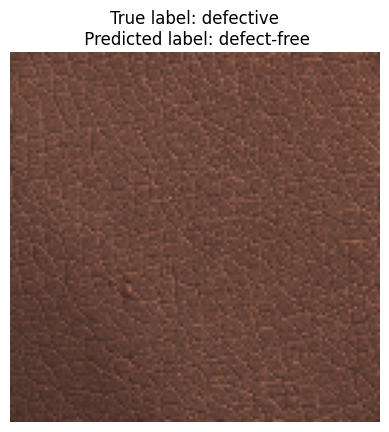

```python
plot_sample_image(df_results)
```

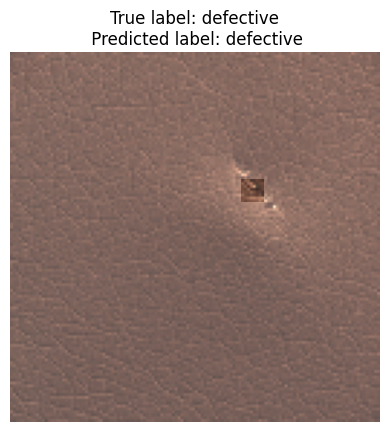

```python
plot_sample_image(df_results)
```